# RCPSP-survival: Explorative analysis

# 1 Introduction

For each instance, several parameters describe the network topology, complexity, and resources (Table 1.1).

Table 1.1: Instance topology, complexity, and resource parameters.

| **Network Topology** |  |
| --- | --- |
| nbAct | Number of activities |
| CNC | Coefficient of Network Complexity |
| OS | Order Strength |
| SP | Serial-Parallel Network Indicator |
| AD | Activity distribution Indicator |
| LA | Length arcs indicator |
| I5 | I5 indicator |
| TF | Total float indicator |
| **Complexity indictors** |  |
| Wprec | Network width (maximal number of activities in parallel in the network), called W in the original study |
| Wall | Instance width (maximal number of activities in parallel considering precedence relations and resource restrictions) (Extension of Wprec, not proposed in any study) |
| NA | General info of the next 4 lines: Feasible sets FS<x><u> indicator denotingthe feasible subsets of <x> normalized by combinations of <x> (in case <u>=1) or by feasible subsets considering only the net… |
| FS21 | FS_1^2 indicator |
| FS22 | FS_2^2 indicator |
| FS31 | FS_1^3 indicator |
| FS32 | FS_2^3 indicator |
| l | Number of linear extentions [not available for all instances; n.f. - not found ] necessary to calculate LE (Equation (4) in the study) |
| f | The number of maximal feasible extentions [not available for all instances; n.f. - not found] |
| LE | Linear extentions indicator (depend on l) |
| FE | Feasible extentions indicator (depend on f) |
| **Resource parameters** |  |
| nbR | Number of resources |
| RF | Resource factor |
| RU | Resource use |
| RS | Resource strength |
| RC | Resource constraintness |
| nblR | Number of resources in lowRU instance version |
| lRF | RF for lowRU instance |
| lRU | RU for lowRU instance |
| lRS | RS for lowRU instance |
| lRC | RC for lowRU instance |
| nbhR | Number of resources in highRD instance version |
| hRF | RF for highRD instance |
| hRU | RU for highRD instance |
| hRS | RS for highRD instance |
| hRC | RC for highRD instance |

# 2 Results

## 2.1 CV dataset

As of September 2023, three different authors have submitted their run-time results and best (or optimal) solution to each of the instances; - Coelho and Vanhoucke (2020) designed this dataset with difficult to solve instances and provided their solutions to some of them. - Watermeyer and Zimmermann (2022) was the first one to add further solutions to improve upon the already achieved results. - Creemers (2021) recently added his results and is able to solve almost all instances.

In this chapter, we compare the run times reported by each of the researchers for each of the instances. If a researcher is unable to find the optimal solution (within a certain time limit), they might still report the best solution that was found.

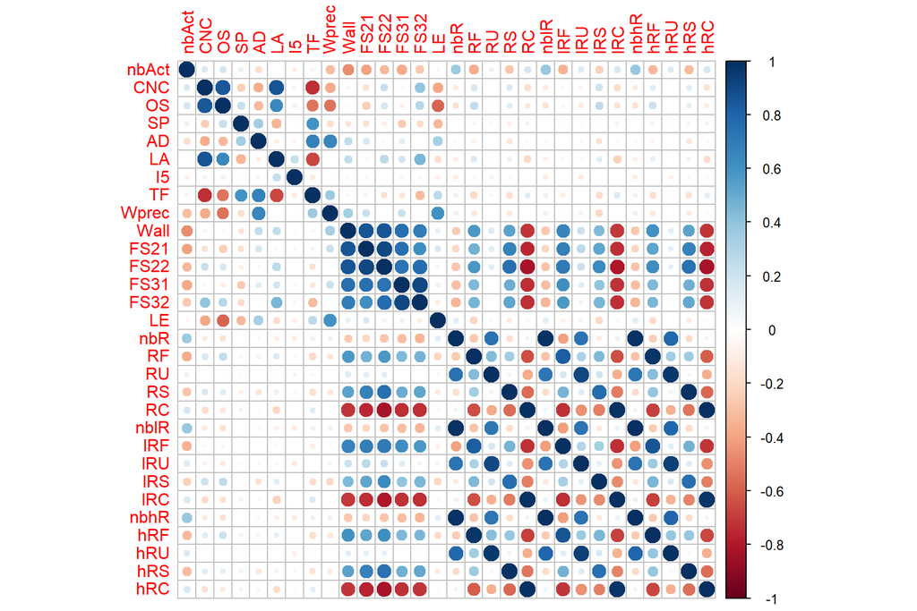

Figure 2.1: Correlation between the different numeric parameters of interest.

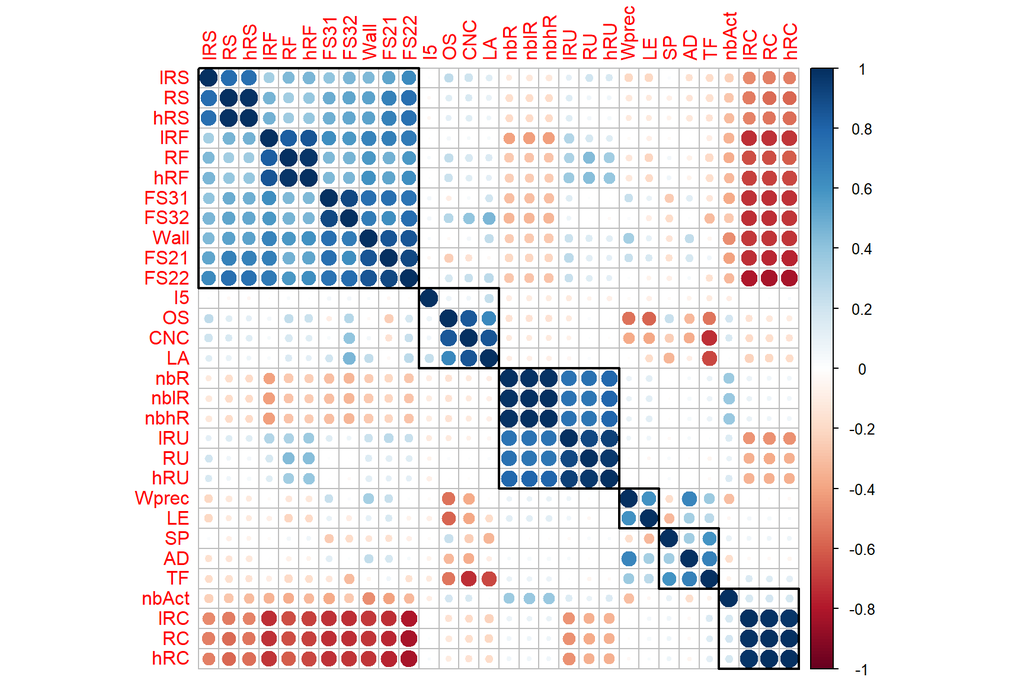

Figure 2.2: Correlation between the different numeric parameters of interest (hierarchical clustering reordering).

### 2.1.1 Run times: Kaplan Meier

In this chapter, we look at the different run times to find an optimal solution. If an optimal solution is not found, a lower bound and/or heuristic solution was reported instead. If a non-optimal solution is reported, we consider the run time to be right-censored.

Figure 2.3 shows the run times for different authors. It can be seen than Coelho and Vanhoucke (2020) solves none of the instances to optimality. They designed this dataset to be difficult such that it can serve as a benchmarking dataset for new RCPSP algorithms. Watermeyer and Zimmermann (2022) can solve almost 30% of all instances to optimality. Since they stop their algorithm after 3600 seconds, all other instances are right censored at that time. Lastly, Creemers (2021) allows for a maximum run time of 48 hours. If no optimal solution is found after that, the instance is right-censored.

Table 2.1 shows different quantiles for each author with log-log 95% confidence intervals.

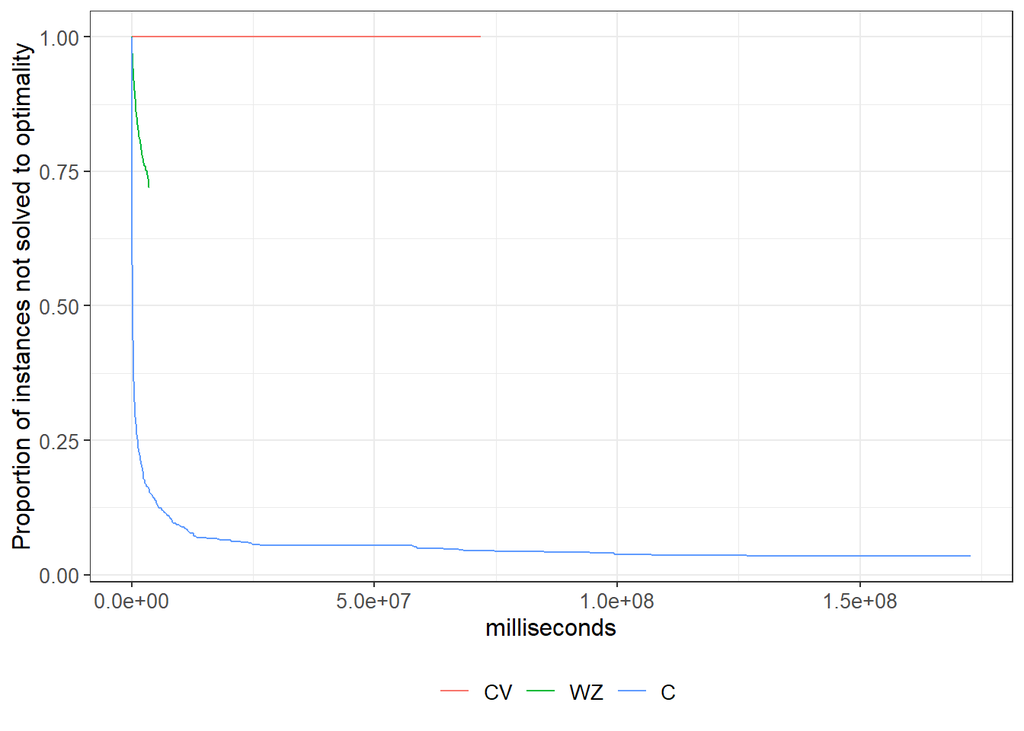

Figure 2.3: Comparing the run time for the different authors.

Table 2.1: Quantiles and confidence intervals for the time to solve to optimality.

| author | q90 | q75 | q50 | q25 | q10 |
| --- | --- | --- | --- | --- | --- |
| CV | Inf, [Inf, Inf] | Inf, [Inf, Inf] | Inf, [Inf, Inf] | Inf, [Inf, Inf] | Inf, [Inf, Inf] |
| WZ | 614162, [426204, 801512] | 3129820, [2137160, Inf] | Inf, [Inf, Inf] | Inf, [Inf, Inf] | Inf, [Inf, Inf] |
| C | 6123, [2093, 7873] | 30992, [22463, 47960] | 212940, [171057, 245239] | 1297992, [818495, 1793611] | 8344589, [5605280, 12018995] |

### 2.1.2 Runtime with different instance parameters

#### 2.1.2.1 Analysis of the Nbact parameter

The nbAct parameter takes values between 20 and 30. nbAct is defined as “Number of activities”. It is split up in 3 equal-sized discrete bins (same number of instances in each bin). We now compare the run times for instances in each of the 3 bins for both Watermeyer and Zimmermann (2022) and Creemers (2021).

Figure 2.4 shows the different Kaplan- Meier curves.

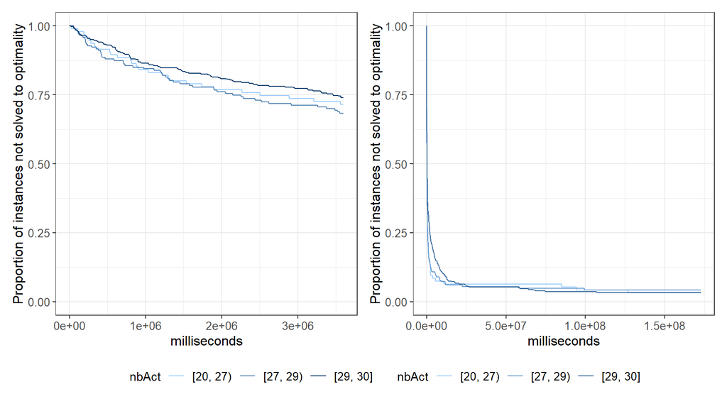

Figure 2.4: Comparing the run time for WZ (left) and C (right). Note that the x-axis does not match

#### 2.1.2.2 Analysis of the Cnc parameter

The CNC parameter takes values between 0.087 and 7.167. CNC is defined as “Coefficient of Network Complexity”. It is split up in 4 equal-sized discrete bins (same number of instances in each bin). We now compare the run times for instances in each of the 4 bins for both Watermeyer and Zimmermann (2022) and Creemers (2021).

Figure 2.5 shows the different Kaplan- Meier curves.

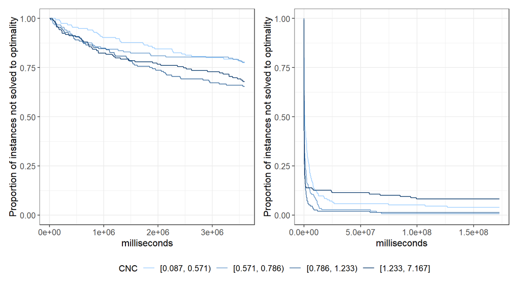

Figure 2.5: Comparing the run time for WZ (left) and C (right). Note that the x-axis does not match

#### 2.1.2.3 Analysis of the Os parameter

The OS parameter takes values between 0.007 and 0.533. OS is defined as “Order Strength”. It is split up in 4 equal-sized discrete bins (same number of instances in each bin). We now compare the run times for instances in each of the 4 bins for both Watermeyer and Zimmermann (2022) and Creemers (2021).

Figure 2.6 shows the different Kaplan- Meier curves.

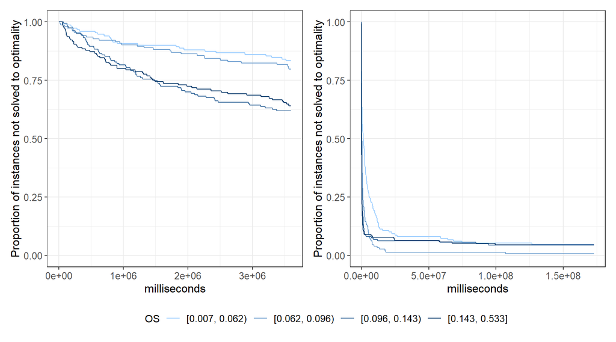

Figure 2.6: Comparing the run time for WZ (left) and C (right). Note that the x-axis does not match

#### 2.1.2.4 Analysis of the Sp parameter

The SP parameter takes values between 0.036 and 0.444. SP is defined as “Serial-Parallel Network Indicator”. It is split up in 4 equal-sized discrete bins (same number of instances in each bin). We now compare the run times for instances in each of the 4 bins for both Watermeyer and Zimmermann (2022) and Creemers (2021).

Figure 2.7 shows the different Kaplan- Meier curves.

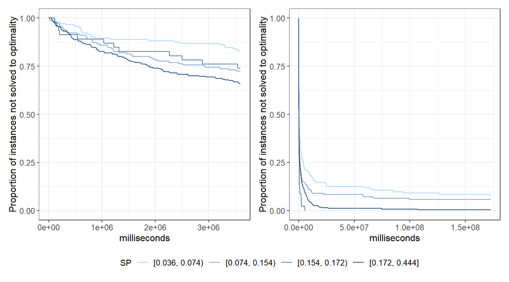

Figure 2.7: Comparing the run time for WZ (left) and C (right). Note that the x-axis does not match

#### 2.1.2.5 Analysis of the Ad parameter

The AD parameter takes values between 0.056 and 1. AD is defined as “Activity distribution Indicator”. It is split up in 4 equal-sized discrete bins (same number of instances in each bin). We now compare the run times for instances in each of the 4 bins for both Watermeyer and Zimmermann (2022) and Creemers (2021).

Figure 2.8 shows the different Kaplan- Meier curves.

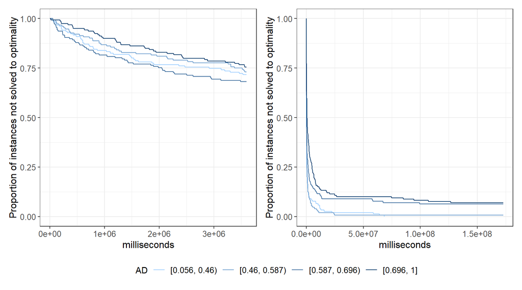

Figure 2.8: Comparing the run time for WZ (left) and C (right). Note that the x-axis does not match

#### 2.1.2.6 Analysis of the La parameter

The LA parameter takes values between 0 and 0.966. LA is defined as “Length arcs indicator”. It is split up in 4 equal-sized discrete bins (same number of instances in each bin). We now compare the run times for instances in each of the 4 bins for both Watermeyer and Zimmermann (2022) and Creemers (2021).

Figure 2.9 shows the different Kaplan- Meier curves.

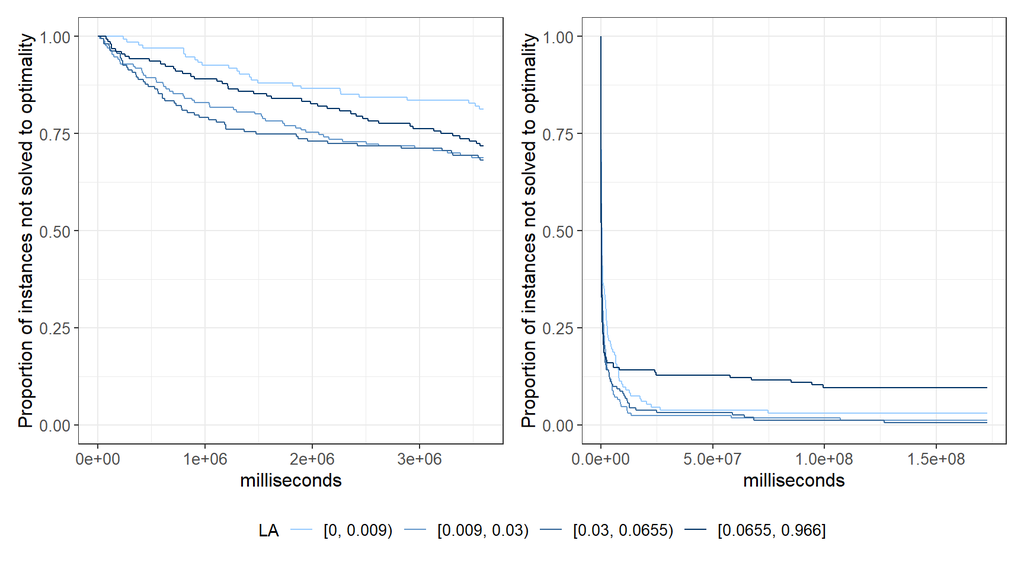

Figure 2.9: Comparing the run time for WZ (left) and C (right). Note that the x-axis does not match

#### 2.1.2.7 Analysis of the I5 parameter

The I5 parameter takes values between 0 and 1. I5 is defined as “I5 indicator”. It is split up in 4 equal-sized discrete bins (same number of instances in each bin). We now compare the run times for instances in each of the 4 bins for both Watermeyer and Zimmermann (2022) and Creemers (2021).

Figure 2.10 shows the different Kaplan- Meier curves.

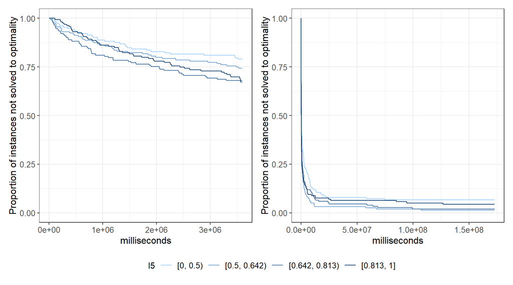

Figure 2.10: Comparing the run time for WZ (left) and C (right). Note that the x-axis does not match

#### 2.1.2.8 Analysis of the Tf parameter

The TF parameter takes values between 0 and 1. TF is defined as “Total float indicator”. It is split up in 4 equal-sized discrete bins (same number of instances in each bin). We now compare the run times for instances in each of the 4 bins for both Watermeyer and Zimmermann (2022) and Creemers (2021).

Figure 2.11 shows the different Kaplan- Meier curves.

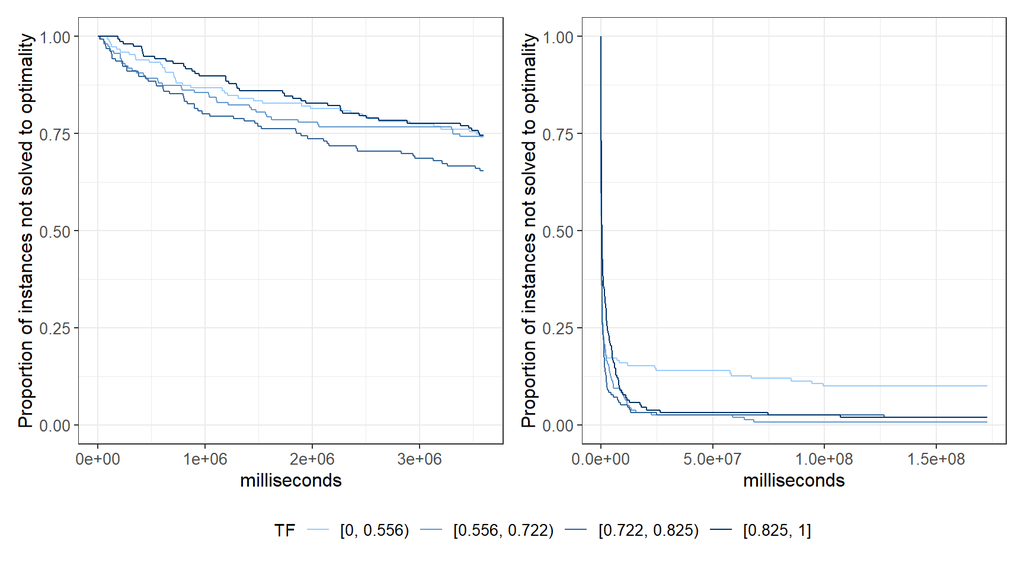

Figure 2.11: Comparing the run time for WZ (left) and C (right). Note that the x-axis does not match

#### 2.1.2.9 Analysis of the Wprec parameter

The Wprec parameter takes values between 0.413 and 0.954. Wprec is defined as “Network width (maximal number of activities in parallel in the network), called W in the original study”. It is split up in 4 equal-sized discrete bins (same number of instances in each bin). We now compare the run times for instances in each of the 4 bins for both Watermeyer and Zimmermann (2022) and Creemers (2021).

Figure 2.12 shows the different Kaplan- Meier curves.

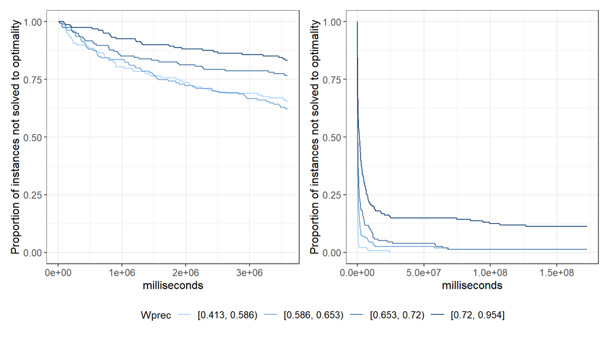

Figure 2.12: Comparing the run time for WZ (left) and C (right). Note that the x-axis does not match

#### 2.1.2.10 Analysis of the Wall parameter

The Wall parameter takes values between 0.068 and 0.892. Wall is defined as “Instance width (maximal number of activities in parallel considering precedence relations and resource restrictions) (Extension of Wprec, not proposed in any study)”. It is split up in 4 equal-sized discrete bins (same number of instances in each bin). We now compare the run times for instances in each of the 4 bins for both Watermeyer and Zimmermann (2022) and Creemers (2021).

Figure 2.13 shows the different Kaplan- Meier curves.

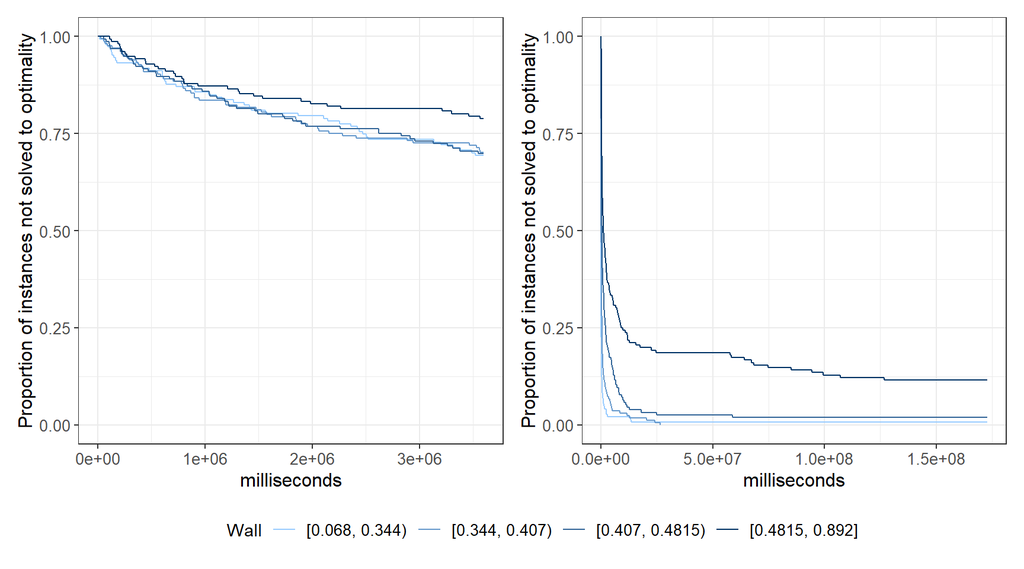

Figure 2.13: Comparing the run time for WZ (left) and C (right). Note that the x-axis does not match

#### 2.1.2.11 Analysis of the Fs21 parameter

The FS21 parameter takes values between 0.218 and 0.98. FS21 is defined as “FS_1^2 indicator”. It is split up in 4 equal-sized discrete bins (same number of instances in each bin). We now compare the run times for instances in each of the 4 bins for both Watermeyer and Zimmermann (2022) and Creemers (2021).

Figure 2.14 shows the different Kaplan- Meier curves.

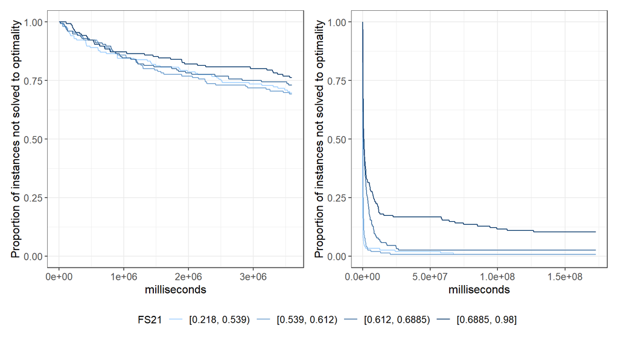

Figure 2.14: Comparing the run time for WZ (left) and C (right). Note that the x-axis does not match

#### 2.1.2.12 Analysis of the Fs22 parameter

The FS22 parameter takes values between 0.23 and 1. FS22 is defined as “FS_2^2 indicator”. It is split up in 4 equal-sized discrete bins (same number of instances in each bin). We now compare the run times for instances in each of the 4 bins for both Watermeyer and Zimmermann (2022) and Creemers (2021).

Figure 2.15 shows the different Kaplan- Meier curves.

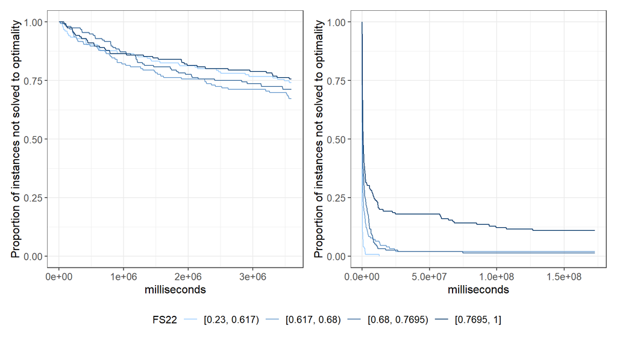

Figure 2.15: Comparing the run time for WZ (left) and C (right). Note that the x-axis does not match

#### 2.1.2.13 Analysis of the Fs31 parameter

The FS31 parameter takes values between 0.024 and 0.762. FS31 is defined as “FS_1^3 indicator”. It is split up in 4 equal-sized discrete bins (same number of instances in each bin). We now compare the run times for instances in each of the 4 bins for both Watermeyer and Zimmermann (2022) and Creemers (2021).

Figure 2.16 shows the different Kaplan- Meier curves.

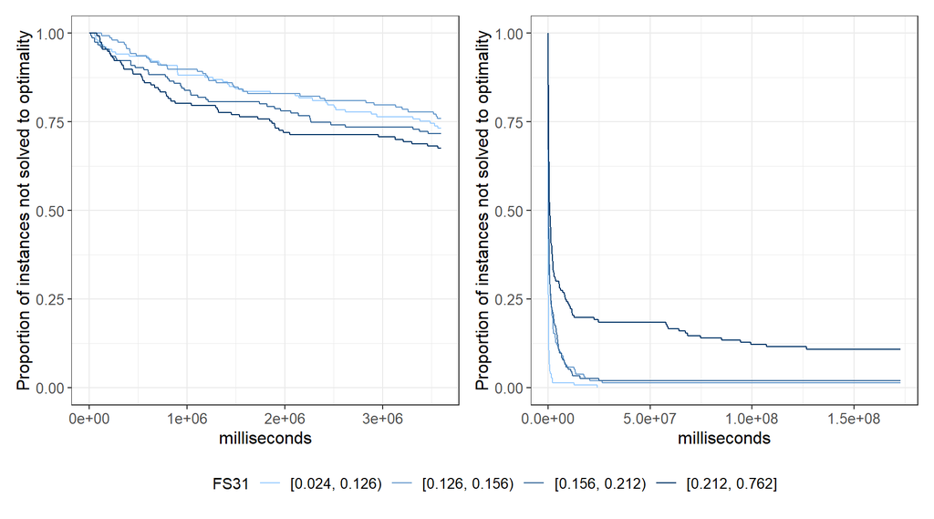

Figure 2.16: Comparing the run time for WZ (left) and C (right). Note that the x-axis does not match

#### 2.1.2.14 Analysis of the Fs32 parameter

The FS32 parameter takes values between 0.027 and 0.933. FS32 is defined as “FS_2^3 indicator”. It is split up in 4 equal-sized discrete bins (same number of instances in each bin). We now compare the run times for instances in each of the 4 bins for both Watermeyer and Zimmermann (2022) and Creemers (2021).

Figure 2.17 shows the different Kaplan- Meier curves.

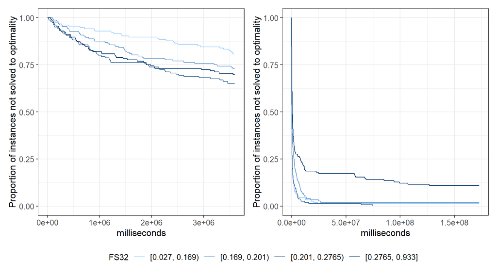

Figure 2.17: Comparing the run time for WZ (left) and C (right). Note that the x-axis does not match

#### 2.1.2.15 Analysis of the Le parameter

The LE parameter takes values between 0.5869512 and 1.4323302. LE is defined as “Linear extentions indicator (depend on l)”. It is split up in 4 equal-sized discrete bins (same number of instances in each bin). We now compare the run times for instances in each of the 4 bins for both Watermeyer and Zimmermann (2022) and Creemers (2021).

Figure 2.18 shows the different Kaplan- Meier curves.

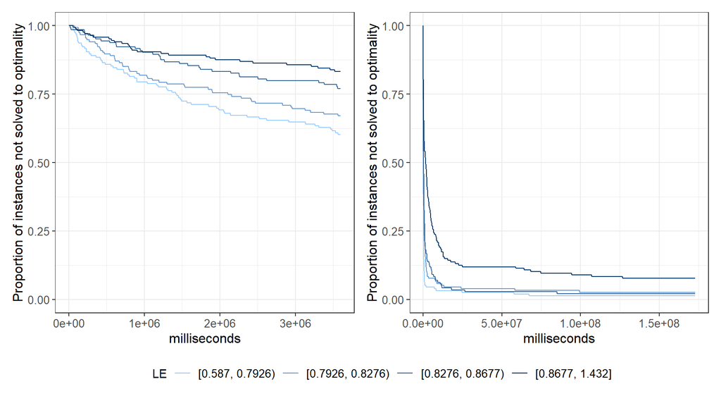

Figure 2.18: Comparing the run time for WZ (left) and C (right). Note that the x-axis does not match

#### 2.1.2.17 Analysis of the Rf parameter

The RF parameter takes values between 0.5 and 1. RF is defined as “Resource factor”. It is split up in 4 equal-sized discrete bins (same number of instances in each bin). We now compare the run times for instances in each of the 4 bins for both Watermeyer and Zimmermann (2022) and Creemers (2021).

Figure 2.20 shows the different Kaplan- Meier curves.

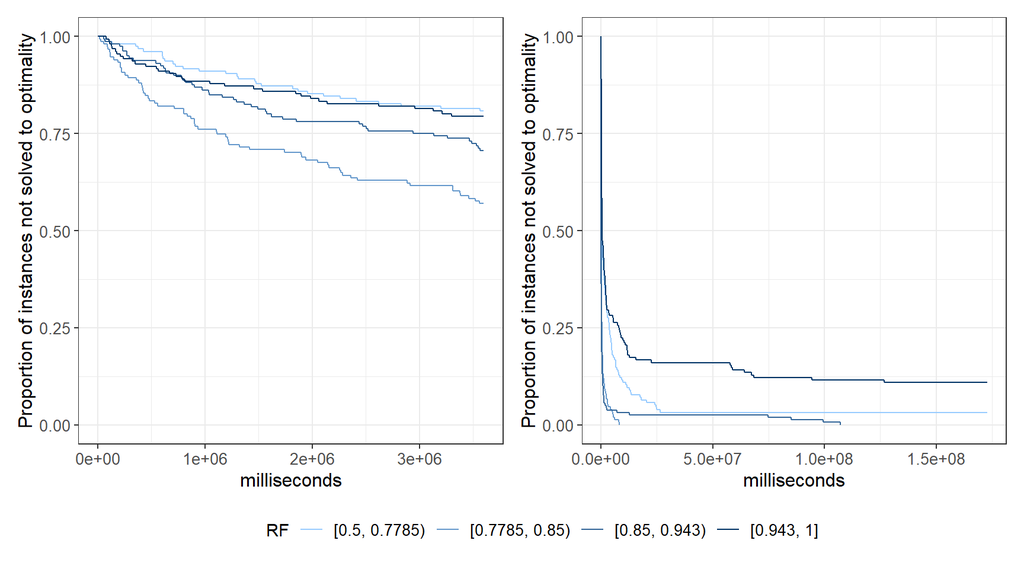

Figure 2.20: Comparing the run time for WZ (left) and C (right). Note that the x-axis does not match

#### 2.1.2.18 Analysis of the Ru parameter

The RU parameter takes values between 1 and 4. RU is defined as “Resource use”. It is split up in 4 equal-sized discrete bins (same number of instances in each bin). We now compare the run times for instances in each of the 4 bins for both Watermeyer and Zimmermann (2022) and Creemers (2021).

Figure 2.21 shows the different Kaplan- Meier curves.

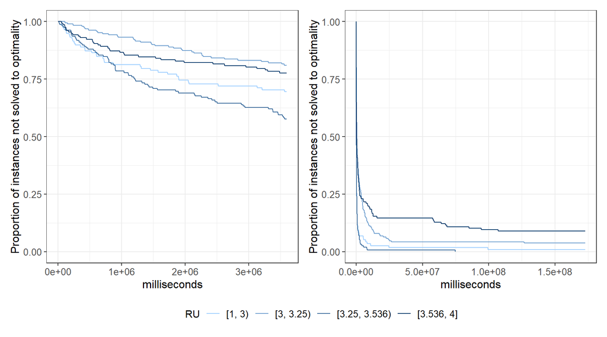

Figure 2.21: Comparing the run time for WZ (left) and C (right). Note that the x-axis does not match

#### 2.1.2.19 Analysis of the Rs parameter

The RS parameter takes values between 0 and 0.245. RS is defined as “Resource strength”. It is split up in 4 equal-sized discrete bins (same number of instances in each bin). We now compare the run times for instances in each of the 4 bins for both Watermeyer and Zimmermann (2022) and Creemers (2021).

Figure 2.22 shows the different Kaplan- Meier curves.

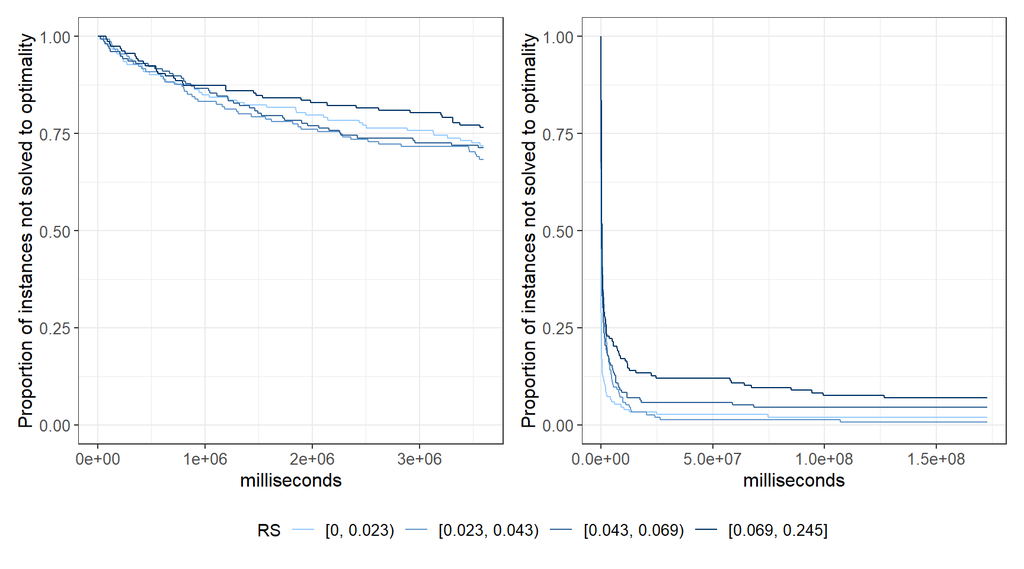

Figure 2.22: Comparing the run time for WZ (left) and C (right). Note that the x-axis does not match

#### 2.1.2.20 Analysis of the Rc parameter

The RC parameter takes values between 0.213 and 0.751. RC is defined as “Resource constraintness”. It is split up in 4 equal-sized discrete bins (same number of instances in each bin). We now compare the run times for instances in each of the 4 bins for both Watermeyer and Zimmermann (2022) and Creemers (2021).

Figure 2.23 shows the different Kaplan- Meier curves.

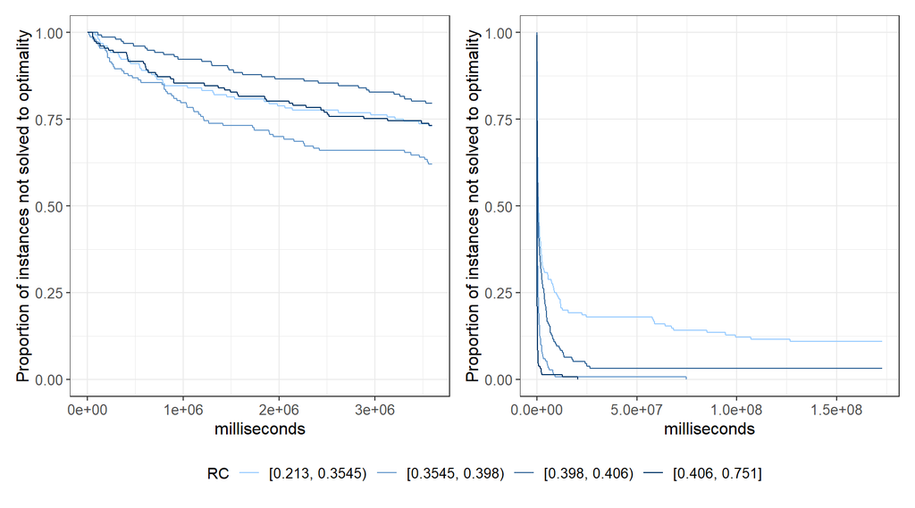

Figure 2.23: Comparing the run time for WZ (left) and C (right). Note that the x-axis does not match

#### 2.1.2.22 Analysis of the Lrf parameter

The lRF parameter takes values between 0.474 and 1. lRF is defined as “RF for lowRU instance”. It is split up in 4 equal-sized discrete bins (same number of instances in each bin). We now compare the run times for instances in each of the 4 bins for both Watermeyer and Zimmermann (2022) and Creemers (2021).

Figure 2.25 shows the different Kaplan- Meier curves.

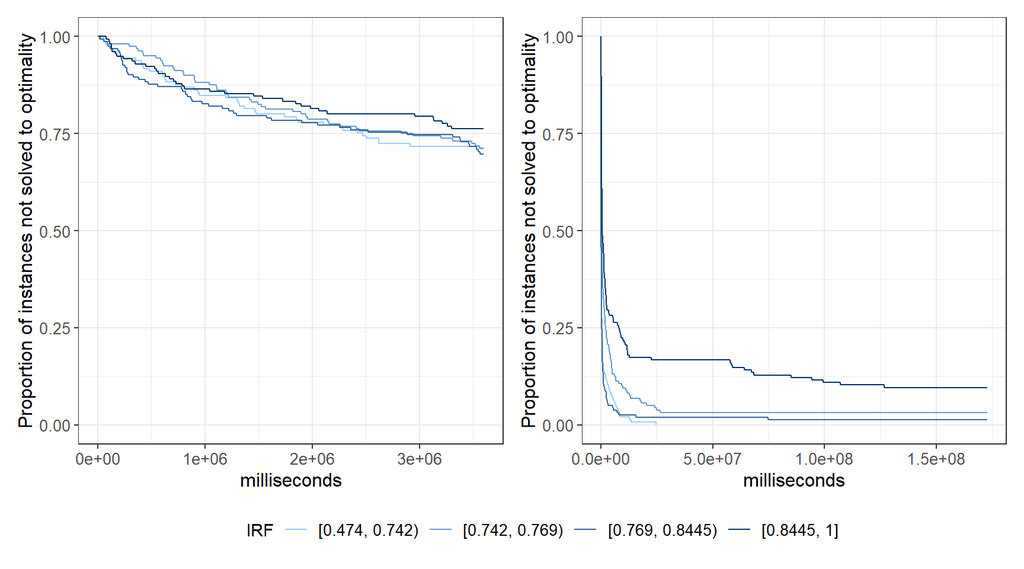

Figure 2.25: Comparing the run time for WZ (left) and C (right). Note that the x-axis does not match

#### 2.1.2.23 Analysis of the Lru parameter

The lRU parameter takes values between 1 and 3.963. lRU is defined as “RU for lowRU instance”. It is split up in 4 equal-sized discrete bins (same number of instances in each bin). We now compare the run times for instances in each of the 4 bins for both Watermeyer and Zimmermann (2022) and Creemers (2021).

Figure 2.26 shows the different Kaplan- Meier curves.

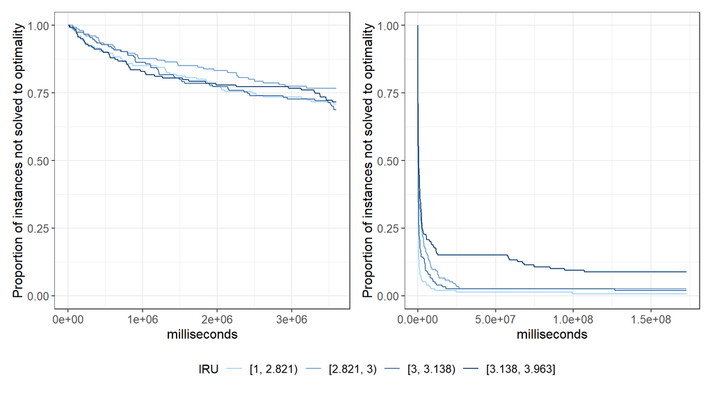

Figure 2.26: Comparing the run time for WZ (left) and C (right). Note that the x-axis does not match

#### 2.1.2.24 Analysis of the Lrs parameter

The lRS parameter takes values between 0 and 0.399. lRS is defined as “RS for lowRU instance”. It is split up in 4 equal-sized discrete bins (same number of instances in each bin). We now compare the run times for instances in each of the 4 bins for both Watermeyer and Zimmermann (2022) and Creemers (2021).

Figure 2.27 shows the different Kaplan- Meier curves.

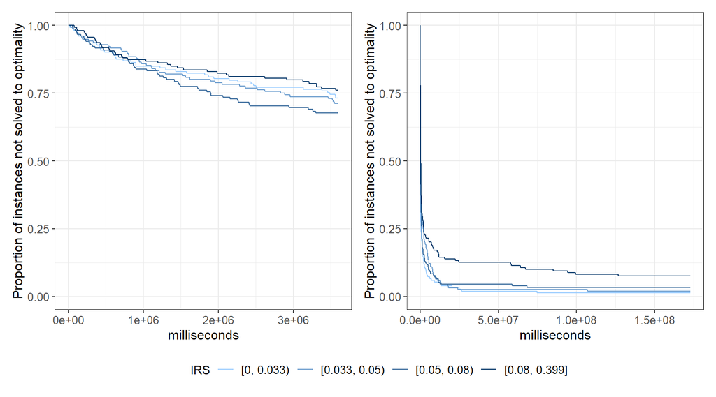

Figure 2.27: Comparing the run time for WZ (left) and C (right). Note that the x-axis does not match

#### 2.1.2.25 Analysis of the Lrc parameter

The lRC parameter takes values between 0.21 and 0.803. lRC is defined as “RC for lowRU instance”. It is split up in 4 equal-sized discrete bins (same number of instances in each bin). We now compare the run times for instances in each of the 4 bins for both Watermeyer and Zimmermann (2022) and Creemers (2021).

Figure 2.28 shows the different Kaplan- Meier curves.

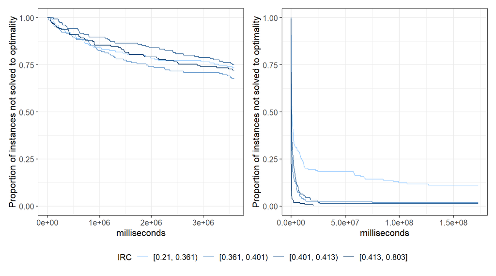

Figure 2.28: Comparing the run time for WZ (left) and C (right). Note that the x-axis does not match

#### 2.1.2.27 Analysis of the Hrf parameter

The hRF parameter takes values between 0.5 and 1. hRF is defined as “RF for highRD instance”. It is split up in 4 equal-sized discrete bins (same number of instances in each bin). We now compare the run times for instances in each of the 4 bins for both Watermeyer and Zimmermann (2022) and Creemers (2021).

Figure 2.30 shows the different Kaplan- Meier curves.

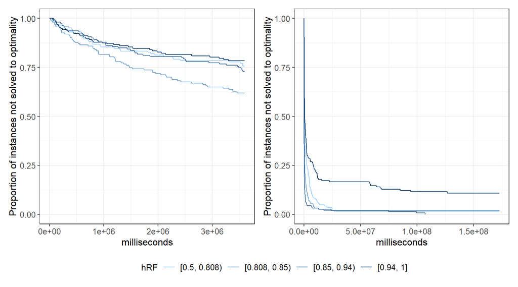

Figure 2.30: Comparing the run time for WZ (left) and C (right). Note that the x-axis does not match

#### 2.1.2.28 Analysis of the Hru parameter

The hRU parameter takes values between 1 and 4. hRU is defined as “RU for highRD instance”. It is split up in 4 equal-sized discrete bins (same number of instances in each bin). We now compare the run times for instances in each of the 4 bins for both Watermeyer and Zimmermann (2022) and Creemers (2021).

Figure 2.31 shows the different Kaplan- Meier curves.

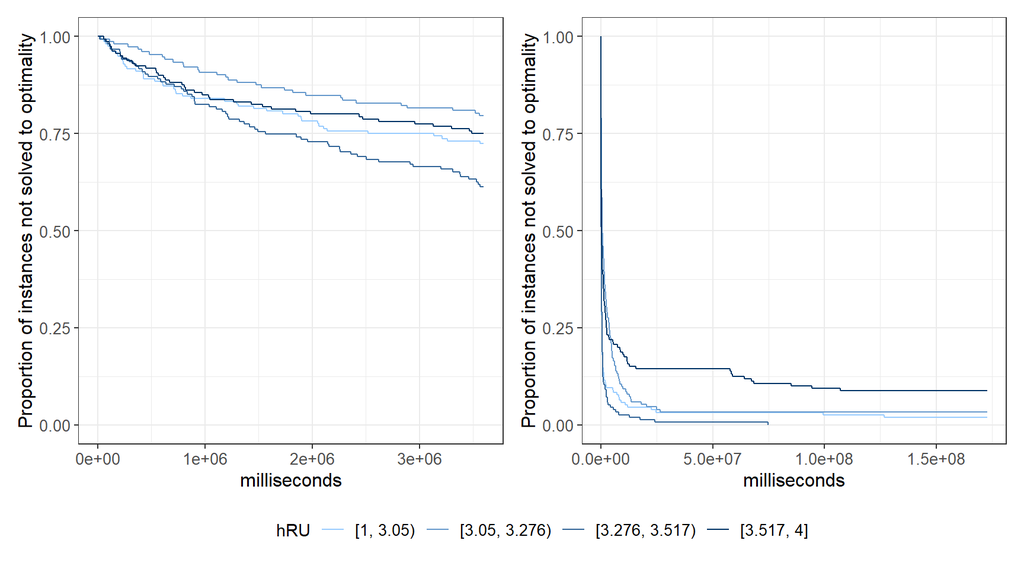

Figure 2.31: Comparing the run time for WZ (left) and C (right). Note that the x-axis does not match

#### 2.1.2.29 Analysis of the Hrs parameter

The hRS parameter takes values between 0 and 0.245. hRS is defined as “RS for highRD instance”. It is split up in 4 equal-sized discrete bins (same number of instances in each bin). We now compare the run times for instances in each of the 4 bins for both Watermeyer and Zimmermann (2022) and Creemers (2021).

Figure 2.32 shows the different Kaplan- Meier curves.

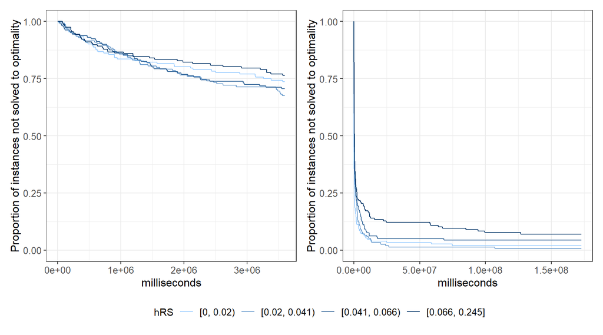

Figure 2.32: Comparing the run time for WZ (left) and C (right). Note that the x-axis does not match

#### 2.1.2.30 Analysis of the Hrc parameter

The hRC parameter takes values between 0.213 and 0.803. hRC is defined as “RC for highRD instance”. It is split up in 4 equal-sized discrete bins (same number of instances in each bin). We now compare the run times for instances in each of the 4 bins for both Watermeyer and Zimmermann (2022) and Creemers (2021).

Figure 2.33 shows the different Kaplan- Meier curves.

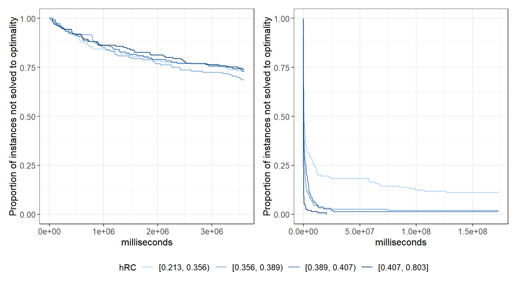

Figure 2.33: Comparing the run time for WZ (left) and C (right). Note that the x-axis does not match

Coelho, José, and Mario Vanhoucke. 2020. “Going to the Core of Hard Resource-Constrained Project Scheduling Instances.” *Computers & Operations Research* 121: 104976. https://doi.org/https://doi.org/10.1016/j.cor.2020.104976.

Creemers, Stefan. 2021. “The Resource-Constrained Project Scheduling Problem: New Benchmark Results, 17th International Workshop on Project Management and Scheduling.” In. PMS. Toulouse, France.

Watermeyer, Kai, and Jürgen Zimmermann. 2022. “A Partition-Based Branch-and-Bound Algorithm for the Project Duration Problem with Partially Renewable Resources and General Temporal Constraints.” *OR Spectrum* 44 (2): 575–602.